# Nobel Prize Trends

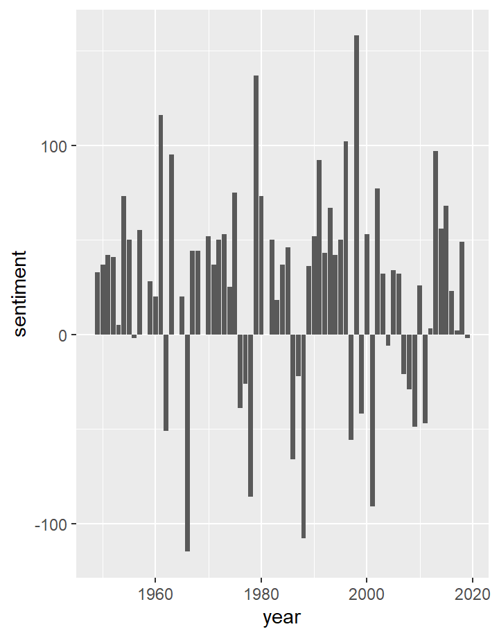

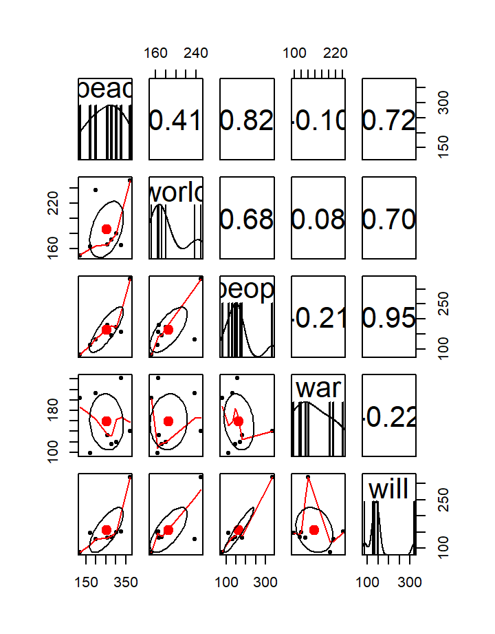

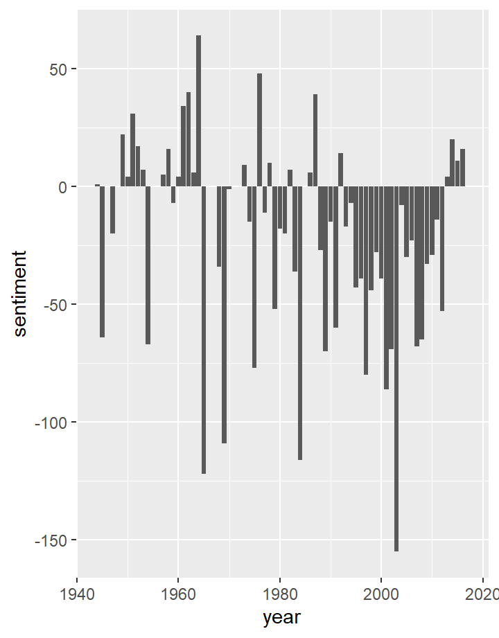

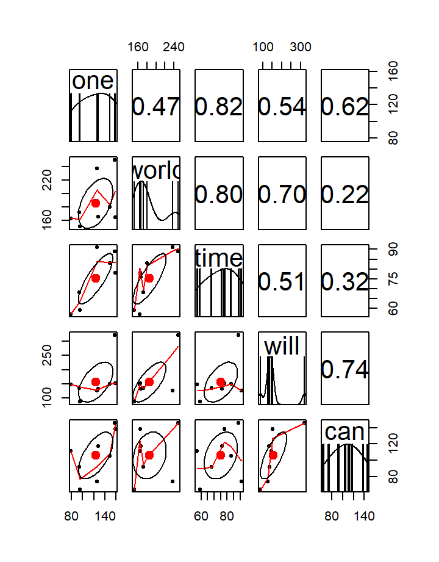

# Why

Quantitative analysis of nobel prize speeches in R

Fun project by Raphael Gall.

One of my favorite speeches is by [William Faulkner](http://www.nobelprize.org/nobel_prizes/literature/laureates/1949/faulkner-speech.html):  
‘[…] There is only the question: When will I be blown up? Because of this, the young man or woman writing today has forgotten *the problems of the human heart in conflict with itself* which alone can make good writing because only that is worth writing about, worth the agony and the sweat.’

I read many nobel speeches over the years. I came across the nobel prize’s website by accident and was just curious to read the acceptance speeches by on the latest prize winners. Then I read the speeches in other categories, and soon I went back regulary and picked random speeches from the past, often from the 80s, 50s or the early 2000s. Even though I am interested in science, I enjoyed the literature and peace categories the most. I guess recipents felt that they had more to say than thank you. Each speech gave me a window into an era that I could relate to only through history class. However, I noticed that the annual record keeping should make it possible to see trends, so I came up with the idea of running an analysis.

Analysis  
The corpus includes all speeches in the literature and peace categories, from today to the 1940s.  
They are publicly available [here](http://www.nobelprize.org).

The text mining process involves:  
* data extraction,  
* summarisation,  
* categorisation,  
* clustering, and  
* visualization.

# Peace

### Trends over the Years

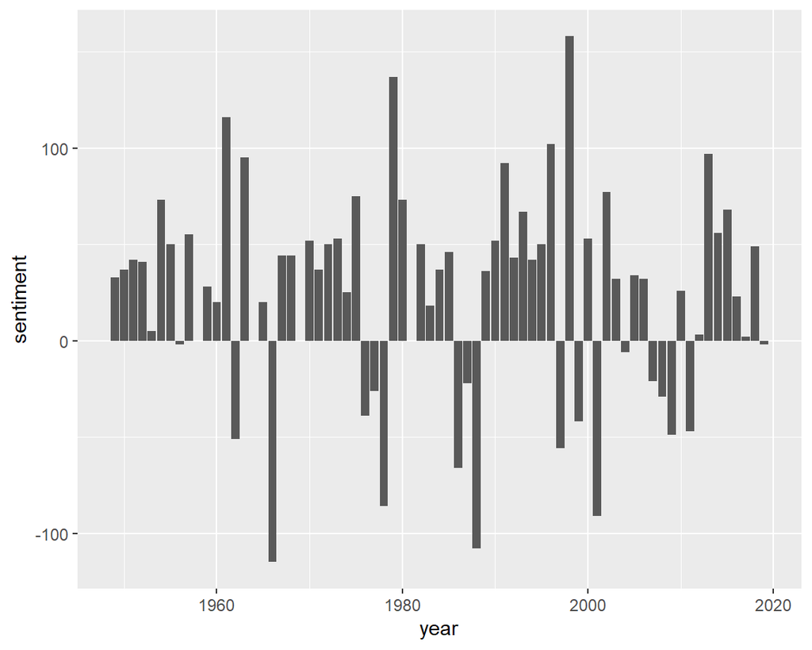

### Peace Prize

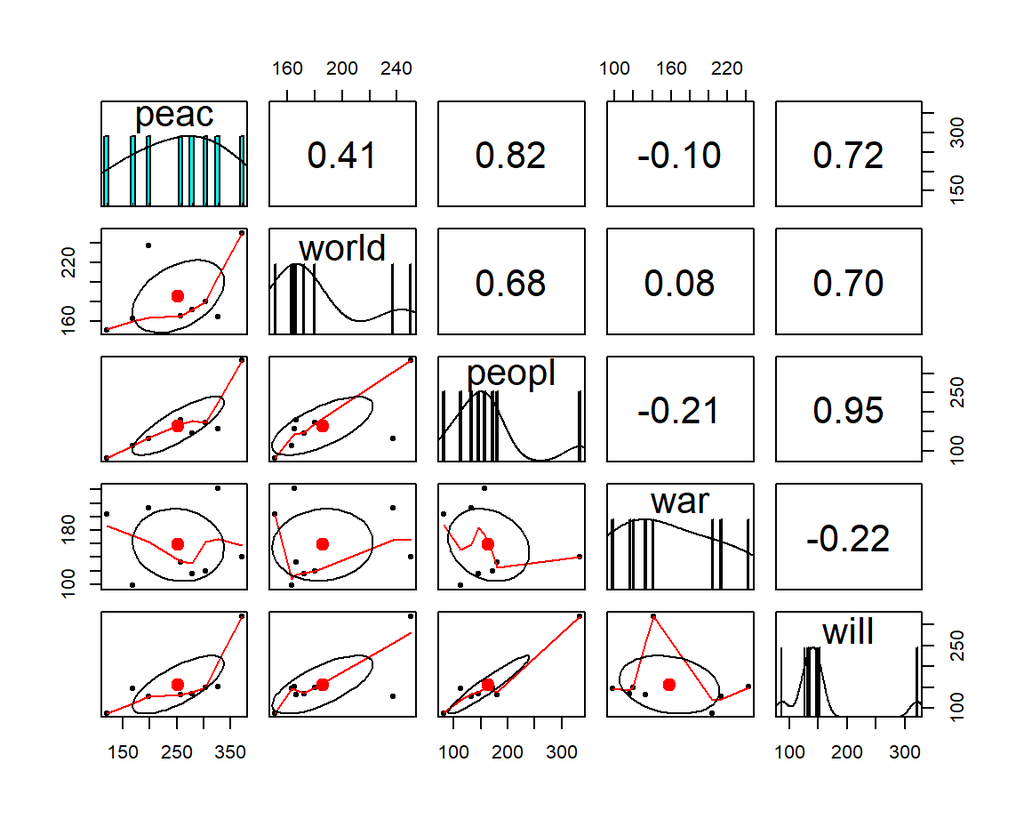

# Literature

### Trends over the Years

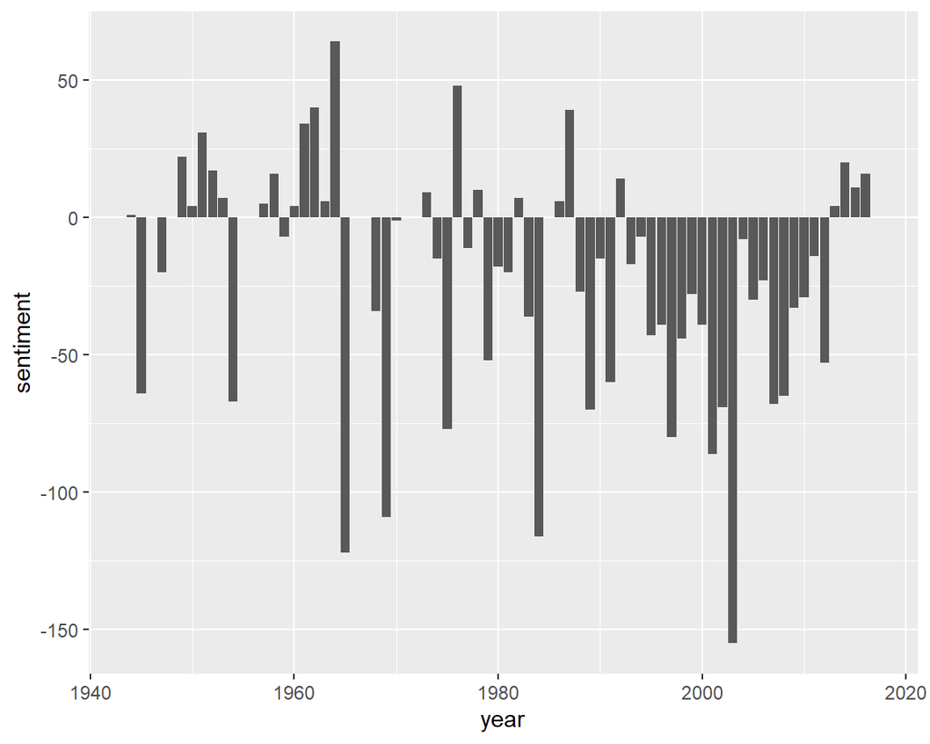

### Literature Prize

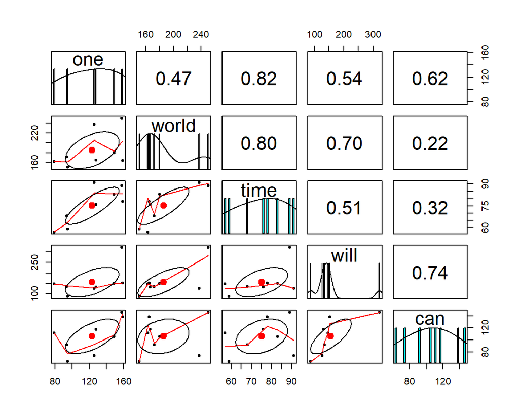